# Lab 3

- Show All Code
- Hide All Code
- View Source

Author

Matthew Chen

# Getting Started

Download starter .qmd file

**Add your preferred YAML**

The downloaded file **does not** contain an YAML, you need to include your own. This allows you to specify how you would like your rendered HTML to look! The sky is the limit!

Download `hiphop.csv`

**Warning**

Save **both** your .qmd file and your data set in the same folder within your Stat 331 directory! **DO NOT** open your .qmd file straight from your downloads folder.

## Tips for Formatting your Lab

**Tip**

- The first chunk of your Quarto document should be to *declare your libraries* (probably only `tidyverse` for now).
- The second chunk of your Quarto document should be to *load in your data* (using the `here()` function!).
- Make sure you address **all the questions** in these instructions.
- If a question requires **any** type of calculation, **you should provide code for your answer!**
- I have provided hints about functions that might be useful to you. You are **not required** to use these functions.
- You may have to Google to solve some of these!
- Be sure to **save** your work regularly (`Ctrl/Cmd + S` or `File > Save` or the floppy disk icon)
- Be sure to **render** your file every so often, to check for errors and make sure it looks nice.
  - Make your Quarto document does not contain `View(dataset)` or `install.packages("package")`, both of these will prevent rendering.
  - Check your Quarto document for moments when you looked at the data by typing the name of the data frame. Leaving these in means the whole dataset will print out and this looks unprofessional.
  - If you are unable to finish due to errors in your code, remember that you can still submit an HTML file if you specify `error: true` in your `execute` options (in the YAML).

# Data Set

The data set `hiphop` contains results from a study conducted by a linguist at the University of Minnesota. The researcher was interested in predicting musical taste based on familiarity with African American English (AAE). 168 subjects participated in the study, and each was asked to define 64 different AAE terms. The definitions given were used to create a `familiarity` score for each subject for each term. This score quantifies how well the subject knew the term on a scale of 1-5 (1 = not at all, 5 = very well). Before tackling the problems, study the description of each variable [here](http://conservancy.umn.edu/bitstream/handle/11299/116327/5/explanationAAEHiphopChesley.txt).

**1. Load the appropriate R packages and import the data set, `hiphop`.**

```r
# code chunk for loading packages and importing the data
#| messages: false
library(tidyverse)
library(dplyr)
library(here)

 hiphop<-read_csv(here("week 3", "hiphop.csv"))
```

## Summary

**2. Provide a brief overview (2-4 sentences) of the data set.**

```r
# you may want to use code to answer this question
view(hiphop)
```

**Note**

It is always good practice to start an analysis by getting a feel for the data and providing a quick summary for readers. You do not need to show any source code for this question, although you probably want to use code to get some information about the data set.

Answer: The study was conducted to ask 168 students about their familiarity with the 64 African American vocabularies that were being listed and other questions mostly related to their taste and knowledge of music. Students who participated in the study will have their sex, age, and ethnicity being recorded as a way to see how will different group of demographics respond to these questions differently. The main goal of the study is to see how widespread African American culture is on contemporary mainstream American society and how it affects different demographics differently. The main variable of interest of this dataset is the variable familiarity. This variable measures each participants’ familiarity with an African American vocabulary based on a likert scale of 1-5. A score of 1 indicates not familiar at all while a score of 5 indicate most familiar. There is also a binary variable called fam1 where participants with a score of 1 in the variable familiarity will have a score of 0 and participants with a score of 2-5 in the variable familiarity will have a score of 1.

**3. What are the rows of this data set?**

**Warning**

It is not one person per row!

```r
# you may want to use code to answer this question
hiphop|>
  distinct(subj,word)|>
  count()
```

```
# A tibble: 1 × 1
      n
  <int>
1 10752
```

Answer: Every single 168 participant has the opportunity to answer questions regarding all the 64 AAE vocabulary so the lists of participants are the same for every word. Therefore, the list of participants in the rows repeat everytime there is a new AAE vocabulary.

## Cleaning the Data

**4. Missing values for some of the variables were replaced with other values. How were missing values replaced? What do you believe are some benefits and drawbacks of doing this?**

```r
# you may want to use code to answer this question


hiphop|>
  summarize(across(asianMove:whiteMove,mean), blackWeekly = mean(blackWeekly))
```

```
# A tibble: 1 × 7
  asianMove blackMove hispanicMove nativeMove SAAMEMove whiteMove blackWeekly
      <dbl>     <dbl>        <dbl>      <dbl>     <dbl>     <dbl>       <dbl>
1     0.754     0.596        0.355     0.0320     0.297      6.28        2.99
```

Answer: Missing values for the series of “Move” variables and the BlackWeekly variable were being replaced by the mean value. Some of the potential drawbacks of replacing missing value with mean include causing the population Standard Deviation to be underestimated and ignoring the issue of outliers. If there is no outliers in the dataset, using the mean would be appropriate.

**5. Clean the data set in whichever ways you see fit. This might mean adjusting *variable type*, for example from `character` to `factor`, or dealing with missing data. Assign your cleaned data set to a new data set named `hiphop_clean` – use this data set going forward.**

**Tip**

Helpful functions: `mutate()`, `as.factor()`

Likert scales (1-5) will be read by R as numeric values and MUST be converted to factors.

It would be most efficient to use `across()` in combination with `mutate()` to complete this task.

```r
# code chunk for Q5



hiphop_clean <- hiphop |>
  mutate(across(.cols = c(familiarity, jayz, jayz1, barkley, boondocks, boondocks1, monique, bieber, word, subj, ethnic,sex),
.fns = ~as.factor(.x)))|>
  select(-one_of("numPreferredArtists","numOverallArtists"))
```

# Data Summaries

**6. How many unique AAE words were studied in this data set?**

**Tip**

Helpful functions: `distinct()`, `count()`

```r
# code chunk for Q6

hiphop_clean|>
  distinct(word)|>
  count()
```

```
# A tibble: 1 × 1
      n
  <int>
1    64
```

Answer: 64 unique AAE words were being studied in the dataset.

**7. Make a new variable that re-categorizes `ethnic` into only two groups, “white” and “non-white”, to simplify your data.**

**Tip**

Helpful functions: `mutate()`, `if_else()`

```r
# code chunk for Q7

hiphop_clean<-hiphop_clean|>
  mutate(race = if_else(ethnic == "white", "white","non-white"))
```

**8. It is fairly common for researchers to collapse ethnic or racial categories similar to what you just did. What are some issues with representing the data in this way?**

Answer: It is not fairly common for researchers to divide racial categories into only “white” or “non-white” because this would assume that white people are the dominant race in the United States while people of color are not considered to be part of the mainstream American culture. It also create a false belief that white people are the default in almost every research regarding each aspect of American society regardless of the type of research. When white people are considered to be the default in research, almost all people of color experiences would be generalize into similar categories but not every racial or ethnic minorities have similar cultural or social experiences despite the fact that almost all of them have faced some kind of racism in the country whether it is direct or indirect. For example, the hardship of Asian American immigrant faced in this country is not the same of the intergenerational trauma that has affected African Americans for several centuries. Therefore, the cultural references of African American hiphop music would not be fully understood by the majority of other racial or ethnic minorities.

**9. What are the demographics of the people in this study? Investigate the variables `sex`, `age`, and `ethnic` and summarize your findings in 1-3 complete sentences.**

**Tip**

You’ll need to first manipulate your data to have each person represented only once.

Helpful functions: `select()`, `distinct(___, .keep_all = TRUE)`, `count()`, `summary()`

```r
# code chunk for Q9


  hiphop_clean|>
  select(subj,sex,age,ethnic)|>
  distinct(subj, .keep_all = TRUE)|>
  summary()
```

```
      subj         sex           age             ethnic
 p1     :  1   Female:117   Min.   :16.00   white   :135
 p10    :  1   Male  : 51   1st Qu.:18.00   asian   : 19
 p101   :  1                Median :19.00   african :  5
 p102   :  1                Mean   :20.02   hispanic:  3
 p103   :  1                3rd Qu.:20.00   indian  :  2
 p105   :  1                Max.   :48.00   biracial:  1
 (Other):162                                (Other) :  3
```

**10. Make at least two plots to display the demographic information of the subjects in this study.**

**Note**

You do not need to discuss these plots, but make sure they are appropriate to the data types and have informative titles and axis labels. Feel free to use the skills you learned in Challenge 2 to enhance your plots!

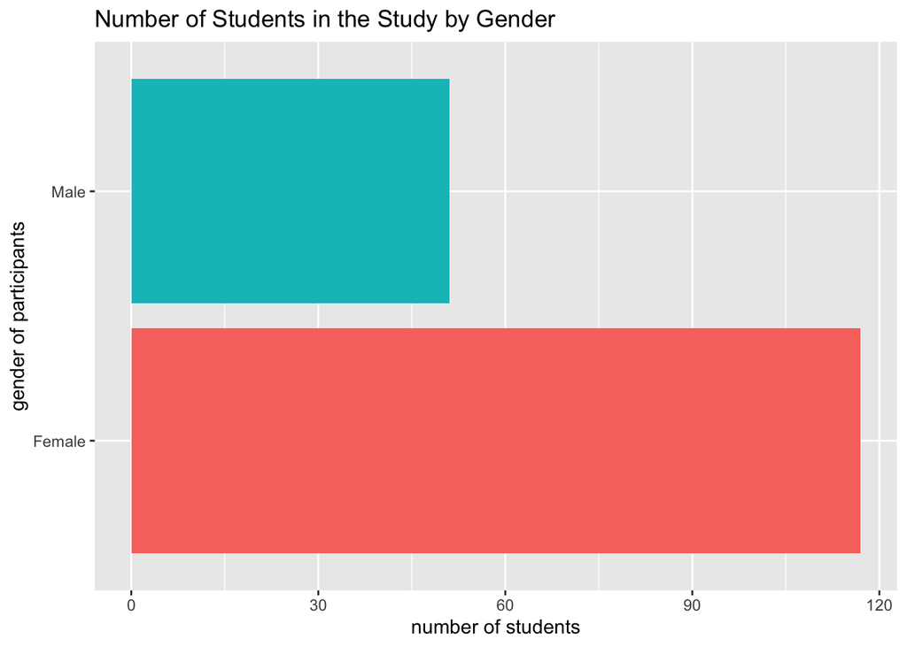

```r
# code chunk for Q10
#Creating a new dataset using demographic information

  demo <-hiphop_clean|>
  select(subj,sex,age,ethnic)|>
  distinct(subj, .keep_all = TRUE)


    #Graph 1

        ggplot(data = demo)+
    geom_bar(mapping = aes(y = sex, fill = sex),show.legend = FALSE)+
          labs(y = "gender of participants", x= "number of students",
  title = "Number of Students in the Study by Gender")
```

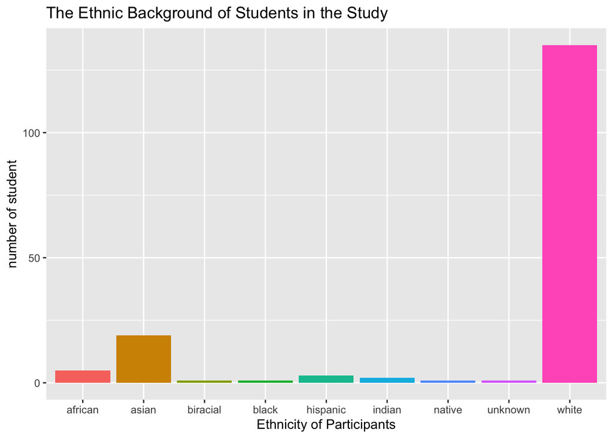

```r
   #Graph 2

        ggplot(data = demo,
  mapping = aes(x = ethnic, fill = ethnic))+
    geom_bar(show.legend = FALSE)+
    labs(x = "Ethnicity of Participants", y = "number of student",
         title = "The Ethnic Background of Students in the Study")
```

## Familiar words

For each demographic group listed below, determine which word(s) in this study was(were) the most **and** least familiar on average.

**Tip**

Helpful functions: `filter()`, `group_by()`, `summarize()`, `slice_max()`, `slice_min()`

Useful variables: `word`, `familiarity`, `sex`, `age`, `ethnic`

**11. People below the age of 20.**

```r
# code chunk for Q11


#least familiar


hiphop_clean|>
   group_by(word)|>
  filter(familiarity ==1,age<20)|>
  summarise(familiarity = n())|>
  slice_max(familiarity)
```

```
# A tibble: 1 × 2
  word             familiarity
  <fct>                  <int>
1 catch the vapors         117
```

```r
# Most familiar

hiphop_clean|>
   group_by(word)|>
  filter(familiarity ==5,age<20)|>
  summarise(familiarity = n())|>
  slice_max(familiarity)
```

```
# A tibble: 1 × 2
  word         familiarity
  <fct>              <int>
1 off the hook          93
```

Answer: The least familiar word for people below the age of 20 is “catch the vapors”. The most familiar word for people below the age of 20 is “off the hook”.

**12. Non-white women.**

```r
# code chunk for Q12
#Least familiar
hiphop_clean|>
   group_by(word)|>
  filter(familiarity ==1,sex =="Female", race == "non-white")|>
  summarise(familiarity = n())|>
  slice_max(familiarity)
```

```
# A tibble: 4 × 2
  word              familiarity
  <fct>                   <int>
1 break someone out          26
2 dukey rope                 26
3 plex                       26
4 rollie                     26
```

```r
#Most familiar

hiphop_clean|>
   group_by(word)|>
  filter(familiarity ==5,sex =="Female", race == "non-white")|>
  summarise(familiarity = n())|>
  slice_max(familiarity)
```

```
# A tibble: 1 × 2
  word    familiarity
  <fct>         <int>
1 feel me          20
```

Answer: The least familiar words for non-white women are “break someone out”, “dukey rope”, “plex”, and “rollie”. The most familiar word for non-white women is “feel me”.

**13. White men above the age of 30.**

```r
# code chunk for Q13

#Least Familiar

hiphop_clean|>
   group_by(word)|>
  filter(familiarity ==1,sex =="Male", race == "white", age>30)|>
  summarise(familiarity = n())|>
  slice_max(familiarity)
```

```
# A tibble: 25 × 2
   word              familiarity
   <fct>                   <int>
 1 ay yo trip                  5
 2 beezy                       5
 3 break someone out           5
 4 catch the vapors            5
 5 crossroads                  5
 6 crump                       5
 7 dap                         5
 8 dollar cab                  5
 9 domino                      5
10 duckets                     5
# … with 15 more rows
```

```r
#Most Familiar
hiphop_clean|>
   group_by(word)|>
  filter(familiarity ==5,sex =="Male", race == "white", age>30)|>
  summarise(familiarity = n())|>
  slice_max(familiarity)
```

```
# A tibble: 1 × 2
  word   familiarity
  <fct>        <int>
1 May-00           4
```

## Study Subjects

A joke among the [Tidy Tuesday](https://www.tidytuesday.com/) community is that Justin Bieber was one of the subjects in this study. Bieber, a white male, from a relatively small town (10,000-60,000 people) in Ontario would have been 17-23 at the time of the study.

**14. Determine which subject you believe is secretly Bieber, justify your answer.**

**Tip**

Refer again to the data set description. There is another clue about Bieber’s identity.

```r
# code chunk for Q14


hiphop_clean|>
  mutate(bieber = as.numeric(bieber))|>
  filter(city > 10000 & city< 60000, age> 17 & age< 23, ethnic == "white", sex == "Male", bieber >= 5)|>
  distinct(subj)
```

```
# A tibble: 1 × 1
  subj
  <fct>
1 p17
```

Answer: I used the filter function to filter out all the criteria that match with the descriptions of Justin Bieber. Justin Bieber belongs to subject p17 because he was a white male that is between age 17 and 23 at that time and he came from a town with a population between 10,000 and 60,000 people. Additionally, he has a Bieber score of 5 or above.

# Lab 3 Submission

You will submit **only** your rendered HTML file. Your HTML file is required to have the following specifications in the YAML options (at the top of your document):

- be self-contained (`self-contained: true`)
- include your source code (`code-tools: true`)
- include all your code and output (`echo: true`)
- include **no** messages from loading in packages or the data (`messages: false`)

**If any of the options are not included, your Lab 3 or Challenge 3 assignment will receive an “Incomplete” and you will be required to submit a revision.**

# Challenge 3: Group Comparisons & Data Ethics

## Published Comparisons

In the published article ([You Know What It Is: Learning Words through Listening to Hip-Hop](https://journals.plos.org/plosone/article/file?id=10.1371/journal.pone.0028248&type=printable)), the author presents a series of comparisons about the variables which most explain an individual’s familiarity with African American English (AAE).

Let us instead compare the number of artists participants reported liking for each genre. Specifically, you will determine which music genre most differentiates each of the demographic groups provided.

> Which genre had much higher average (mean or median) reported artists in one group than the other.
> - Male versus Female
> - White versus Non-White

**Tip**

You might find it helpful to first create a new data set with only the variables you are interested in! Look at the Music Variables in the data set description along with the demographics of interest.

Helpful functions: `select()`, `group_by()`, `summarize()`, `across()`

Other useful operations in R: `mean()`, `diff()`, `abs()`, `which.max()`

## Study Design Critique – Data Ethics

Myself, members of the Tidy Tuesday community, and previous 331 students have voiced concerns regarding the design and social context of this study.

You’ve already read the [data description (link)](http://conservancy.umn.edu/bitstream/handle/11299/116327/5/explanationAAEHiphopChesley.txt) regarding how participants were recruited for participation in this study. **Now**, you need to read additional details regarding aspects of the study in the published paper: [You Know What It Is: Learning Words through Listening to Hip-Hop](https://journals.plos.org/plosone/article/file?id=10.1371/journal.pone.0028248&type=printable).

> Based on the design of this study and its context (African American English), what are **at least two** concerns you have? Keep in mind this critique aligns with conversations regarding data ethics. Thus, your concerns need to address the racial aspects of the design of this study.

# Challenge 3 Submission

Your challenge should be submitted as a **separate file**, **not** at the bottom of your Lab 3 file. Please submit your rendered HTML file. You can copy and paste this code into a **new** Quarto file. Your Challenge 3 submission should only included code necessary for completing the Challenge, nothing else.

You will submit **only** your rendered HTML file. Your HTML file is required to have the following specifications in the YAML options (at the top of your document):

- be self-contained (`self-contained: true`)
- include your source code (`code-tools: true`)
- include all your code and output (`echo: true`)
- include **no** messages from loading in packages or the data (`messages: false`)

**If any of the options are not included, your Lab 3 or Challenge 3 assignment will receive an “Incomplete” and you will be required to submit a revision.**